# Introduction to R

Maria Popescu

## Goals for lab

- Become acquainted with R
- Build a simple tree growth and death model

## Step 1: Knitting a document

Visit https://www.r-project.org to download R. Find the version of R that is appropriate for your operating system.

Visit https://posit.co/download/rstudio-desktop/ to download R Studio. R Studio is an IDE (interactive development environment) for R. It provides tools for easing code writing and helps contain the numerous windows R often opens.

Go to file and under “New File” select “R Markdown…”

Select Document on the left menu, Title is “Lab 1 test”, Author is your name, Select “HTML”.

Click OK to create a new Rmarkdown file.

In the new file, click Knit -> Knit to HTML. If you need to install any packages, please go ahead and install them. Now create the HTML document from the Rmarkdown file. Confirm that a HTML document was created. This exercise test that Rmarkdown works on your computer. You will not turn in this HTML file.

Complete all the questions below and click -> Knit to HTML to create the document that you will turn in.

## Step 2

We are going to use R as a scientific programming language. You may have used R for data science, particularly with the tidyverse family of packages. Here, we use “base R” to do calculations on vectors and arrays for simulation. We will not be using the commonly used “tidyverse R” because we will not be working with data.

A variable is a symbol that is assigned a value. In the code below, a, b, and c are variables. In R, run the following code:

```r
a <- 2
b <- 3
c <- a + b
c
```

```
## [1] 5
```

**Question 1:**

What value do you get for the variable c?

**Answer 1:** 5

**Question 2:**

Use the concept of a variable to calculate the area of a rectangle (a variable called `rect_area`) using variables called `side1` and `side2`. Put the code you used below this question in the code “chunk” (i.e., the lines between the ``` symbols)

**Answer 2:**

```r
#Place your answer here
side1 <- 4
side2 <- 6
rect_area <- side1 * side2
rect_area
```

```
## [1] 24
```

## Step 3: Explore the concept of a function

A function is code that receives inputs and returns outputs. It is defined by the name of the function, followed by a set of parentheses that contains the inputs to the function. We use functions to allow us to repeat calculations in code without having to retype all the code. Instead of retyping many lines of code to repeat calculations, you can create a function and reuse it by typing just the name of the function and providing the inputs.

When naming functions, the name must be a verb so it is easy to understand what “action” the function performs.

The following is an example of a function that calculates the area of a rectangle. The function is named `calc_rect_area`

```r
calc_rect_area <- function(a, b){
  area <- a * b
  return(area)
}
```

The `a` and `b` in the parenthesis after the function are the inputs. Anything in the brackets is performed when the function is called. The value in the parenthesis after the `return` is the value that is output by the function. Anything else in the function is not saved. The following is an example of a function call (be sure that you have run the function code above):

```r
side1 <- 5
side2 <- 40
area <- calc_rect_area(a = side1, b = side2)
area
```

```
## [1] 200
```

**Question 3:**

Using the code above as a template, create a function to calculate the area of a circle given a value for the radius. Put your code below in the code chunk. Remember to have the name of the function be an action.

**Answer 3**

```r
#Insert code for the answer to question 3 here
calc_circ_area <- function(r){
  circ_area <- pi*r^2
  return(circ_area)
}
```

## Step 4: Explore the concept of a scalar, vector, array, and matrix

A scalar is a single number that can be used to multiply by other scalars, vectors, or arrays. Think of it as a number that re-scales another number.

A vector, array, or matrix is a group of numbers or characters that can be referenced using the name of a single variable (variables are also called objects). A vector is a 1-dimensional set of numbers (or characters) that are all the same type (i.e., has to be all numbers or characters). The following is an example of a numerical vector:

```r
a <- c(10, 11, 12, 13, 14, 15, 16, 17, 18, 19, 20)
a
```

```
##  [1] 10 11 12 13 14 15 16 17 18 19 20
```

where the c() is a function because is a word `c` followed directly by parentheses. Run following the command to learn about the function. The `?<insert function name>` command displays the help information for the function.

```r
?c
```

```
## starting httpd help server ... done
```

**Question 4:**

Describe the c() function. What does it do?

**Answer 4:** Concatenates. It combines values into a vector or a list.

You can use an index to reference a ‘cell’ within the vector (1D) or array/matrix (multi-dimensional). Putting an integer in brackets [number] allows you to access that cell of the vector. In the example below, the variable index is set to 1 and is used to access the first element of `a[index].` This is the same `a[1]` because `index` is set to 1.

```r
index <- 1
a[index]
```

```
## [1] 10
```

```r
a[1]
```

```
## [1] 10
```

**Question 5:**

What is the value for the 3rd index of vector a (as defined above)?

**Answer 5:**

```r
#the 3rd index of vector a is 12
a[3]
```

```
## [1] 12
```

An array is a multi-dimensional variable. Use the following code to create an array that has values of 0 in each cell. The `dim` argument in the function is the dimension of the array you are creating. `dim = 10` is a 10-element vector, and `dim = c(10, 20)` is a 10 x 20 matrix with 200 total elements.

Importantly, the first numberis the vertical index (row), and the second number is the horizontal index (column).

```r
a <- array(0, dim = 10)
b <- array(0, dim = c(10, 20))
a
```

```
##  [1] 0 0 0 0 0 0 0 0 0 0
```

```r
b
```

```
##       [,1] [,2] [,3] [,4] [,5] [,6] [,7] [,8] [,9] [,10] [,11] [,12] [,13]
##  [1,]    0    0    0    0    0    0    0    0    0     0     0     0     0
##  [2,]    0    0    0    0    0    0    0    0    0     0     0     0     0
##  [3,]    0    0    0    0    0    0    0    0    0     0     0     0     0
##  [4,]    0    0    0    0    0    0    0    0    0     0     0     0     0
##  [5,]    0    0    0    0    0    0    0    0    0     0     0     0     0
##  [6,]    0    0    0    0    0    0    0    0    0     0     0     0     0
##  [7,]    0    0    0    0    0    0    0    0    0     0     0     0     0
##  [8,]    0    0    0    0    0    0    0    0    0     0     0     0     0
##  [9,]    0    0    0    0    0    0    0    0    0     0     0     0     0
## [10,]    0    0    0    0    0    0    0    0    0     0     0     0     0
##       [,14] [,15] [,16] [,17] [,18] [,19] [,20]
##  [1,]     0     0     0     0     0     0     0
##  [2,]     0     0     0     0     0     0     0
##  [3,]     0     0     0     0     0     0     0
##  [4,]     0     0     0     0     0     0     0
##  [5,]     0     0     0     0     0     0     0
##  [6,]     0     0     0     0     0     0     0
##  [7,]     0     0     0     0     0     0     0
##  [8,]     0     0     0     0     0     0     0
##  [9,]     0     0     0     0     0     0     0
## [10,]     0     0     0     0     0     0     0
```

**Question 6:** What are the dimensions of array a and array b? How many rows? How many columns?

The values in each cell of an array can be replaced using the index. For example, you can replace the value in cell [4,5] with the number 10.

```r
b[4, 5] <- 10
b
```

```
##       [,1] [,2] [,3] [,4] [,5] [,6] [,7] [,8] [,9] [,10] [,11] [,12] [,13]
##  [1,]    0    0    0    0    0    0    0    0    0     0     0     0     0
##  [2,]    0    0    0    0    0    0    0    0    0     0     0     0     0
##  [3,]    0    0    0    0    0    0    0    0    0     0     0     0     0
##  [4,]    0    0    0    0   10    0    0    0    0     0     0     0     0
##  [5,]    0    0    0    0    0    0    0    0    0     0     0     0     0
##  [6,]    0    0    0    0    0    0    0    0    0     0     0     0     0
##  [7,]    0    0    0    0    0    0    0    0    0     0     0     0     0
##  [8,]    0    0    0    0    0    0    0    0    0     0     0     0     0
##  [9,]    0    0    0    0    0    0    0    0    0     0     0     0     0
## [10,]    0    0    0    0    0    0    0    0    0     0     0     0     0
##       [,14] [,15] [,16] [,17] [,18] [,19] [,20]
##  [1,]     0     0     0     0     0     0     0
##  [2,]     0     0     0     0     0     0     0
##  [3,]     0     0     0     0     0     0     0
##  [4,]     0     0     0     0     0     0     0
##  [5,]     0     0     0     0     0     0     0
##  [6,]     0     0     0     0     0     0     0
##  [7,]     0     0     0     0     0     0     0
##  [8,]     0     0     0     0     0     0     0
##  [9,]     0     0     0     0     0     0     0
## [10,]     0     0     0     0     0     0     0
```

**Question 7:**

In array `b`, replace the value in the cell with column number 5 and row number 7 with the value of 100. After replacing the value, type the command `b` to show the array. Provide your code below.

**Answer 7:**

```r
b[7, 5] <- 100
b
```

```
##       [,1] [,2] [,3] [,4] [,5] [,6] [,7] [,8] [,9] [,10] [,11] [,12] [,13]
##  [1,]    0    0    0    0    0    0    0    0    0     0     0     0     0
##  [2,]    0    0    0    0    0    0    0    0    0     0     0     0     0
##  [3,]    0    0    0    0    0    0    0    0    0     0     0     0     0
##  [4,]    0    0    0    0   10    0    0    0    0     0     0     0     0
##  [5,]    0    0    0    0    0    0    0    0    0     0     0     0     0
##  [6,]    0    0    0    0    0    0    0    0    0     0     0     0     0
##  [7,]    0    0    0    0  100    0    0    0    0     0     0     0     0
##  [8,]    0    0    0    0    0    0    0    0    0     0     0     0     0
##  [9,]    0    0    0    0    0    0    0    0    0     0     0     0     0
## [10,]    0    0    0    0    0    0    0    0    0     0     0     0     0
##       [,14] [,15] [,16] [,17] [,18] [,19] [,20]
##  [1,]     0     0     0     0     0     0     0
##  [2,]     0     0     0     0     0     0     0
##  [3,]     0     0     0     0     0     0     0
##  [4,]     0     0     0     0     0     0     0
##  [5,]     0     0     0     0     0     0     0
##  [6,]     0     0     0     0     0     0     0
##  [7,]     0     0     0     0     0     0     0
##  [8,]     0     0     0     0     0     0     0
##  [9,]     0     0     0     0     0     0     0
## [10,]     0     0     0     0     0     0     0
```

## Step 5: Explore the concept of a ‘for loop’

A ‘for loop’ steps through a sequence of numbers. In a ‘for loop’ the variable before ‘in’ is the index variable and the numbers after are the sequence (in the case below - from 1 to 10). Run the following code

```r
loop_length <- 10
sequence <- seq(1, loop_length, by = 1)
for(i in sequence){
  print("Pass through loop")
  print(i)
}
```

```
## [1] "Pass through loop"
## [1] 1
## [1] "Pass through loop"
## [1] 2
## [1] "Pass through loop"
## [1] 3
## [1] "Pass through loop"
## [1] 4
## [1] "Pass through loop"
## [1] 5
## [1] "Pass through loop"
## [1] 6
## [1] "Pass through loop"
## [1] 7
## [1] "Pass through loop"
## [1] 8
## [1] "Pass through loop"
## [1] 9
## [1] "Pass through loop"
## [1] 10
```

You will see that i increased by 1 each time through the loop. We can now use variable i, which changes through the loop, to access different rows or columns in an array.

Imagine that you want to replace all of the cells in the 2nd row of the ‘b’ array with the value of 6. You do the following:

```r
b[2, 1] <- 6
b[2, 2] <- 6
b[2, 3] <- 6
b[2, 4] <- 6
b[2, 5] <- 6
b[2, 6] <- 6
b[2, 7] <- 6
b[2, 8] <- 6
b[2, 9] <- 6
b[2, 10] <- 6
```

Alternatively, you could do the following

```r
i <- 1
b[2, i] <- 6
i <- 2
b[2, i] <- 6
i <- 3
b[2, i] <- 6
i <- 4
b[2, i] <- 6
i <- 5
b[2, i] <- 6
i <- 6
b[2, i] <- 6
i <- 7
b[2, i] <- 6
i <- 8
b[2, i] <- 6
i <- 9
b[2, i] <- 6
i <- 10
b[2, i] <- 6
```

Both require writing a lot of repetitive code and are prone to errors, especially with a large array. Notice how the only thing that differs is the column index (which increases from 1 to 10, just like the index i in the for loop above).

**Question 8:**

Use a ‘for loop’ to replace all of the cells in the 2nd row of the ‘b’ array with the value of 7. Provide your code below.

**Answer 8:**

```r
#insert answer to question 8 here

sequence <- seq(1, 20, by = 1)
for(i in sequence){
  b[2, i]<- 7
}
b
```

```
##       [,1] [,2] [,3] [,4] [,5] [,6] [,7] [,8] [,9] [,10] [,11] [,12] [,13]
##  [1,]    0    0    0    0    0    0    0    0    0     0     0     0     0
##  [2,]    7    7    7    7    7    7    7    7    7     7     7     7     7
##  [3,]    0    0    0    0    0    0    0    0    0     0     0     0     0
##  [4,]    0    0    0    0   10    0    0    0    0     0     0     0     0
##  [5,]    0    0    0    0    0    0    0    0    0     0     0     0     0
##  [6,]    0    0    0    0    0    0    0    0    0     0     0     0     0
##  [7,]    0    0    0    0  100    0    0    0    0     0     0     0     0
##  [8,]    0    0    0    0    0    0    0    0    0     0     0     0     0
##  [9,]    0    0    0    0    0    0    0    0    0     0     0     0     0
## [10,]    0    0    0    0    0    0    0    0    0     0     0     0     0
##       [,14] [,15] [,16] [,17] [,18] [,19] [,20]
##  [1,]     0     0     0     0     0     0     0
##  [2,]     7     7     7     7     7     7     7
##  [3,]     0     0     0     0     0     0     0
##  [4,]     0     0     0     0     0     0     0
##  [5,]     0     0     0     0     0     0     0
##  [6,]     0     0     0     0     0     0     0
##  [7,]     0     0     0     0     0     0     0
##  [8,]     0     0     0     0     0     0     0
##  [9,]     0     0     0     0     0     0     0
## [10,]     0     0     0     0     0     0     0
```

In the for-loop above, we used a vector called `sequence` to represent the vector of elements we wanted to loop through. The same vector can be created using the following code

```r
1:loop_length
```

```
##  [1]  1  2  3  4  5  6  7  8  9 10
```

Using this idea, a for-loop is more commonly written as follows, where the `1:loop_length` is directly used in the for-loop call:

```r
loop_length <- 10
for(i in 1:loop_length){
  print("Pass through loop")
  print(i)
}
```

```
## [1] "Pass through loop"
## [1] 1
## [1] "Pass through loop"
## [1] 2
## [1] "Pass through loop"
## [1] 3
## [1] "Pass through loop"
## [1] 4
## [1] "Pass through loop"
## [1] 5
## [1] "Pass through loop"
## [1] 6
## [1] "Pass through loop"
## [1] 7
## [1] "Pass through loop"
## [1] 8
## [1] "Pass through loop"
## [1] 9
## [1] "Pass through loop"
## [1] 10
```

## Step 6: Grow a tree using a “for loop”

The concept of a ‘for loop’ and an array can be combined to simulate the growth of an individual tree. Imagine that the growth (net primary productivity) of a tree is 300 g C m-2 and is constant through time.

```r
npp <- 300
```

We want to predict the growth of the tree for 200 years

```r
simulation_years <- 200
```

Create an array to store the size of the tree each year. This is a 1-D array (so it is actually a vector)

```r
veg <- array(data = NA, dim = c(simulation_years))
```

`veg` is a vector of `NA` (which means ‘no value’) with a cell for each year. Set the initial value (year 1) of 1 g C m-2

```r
veg[1] <- 1
```

Use a “for loop” to progress through the years. One key is that you need to start the sequence at 2 because you already know the size of the tree at year 1. To grow the tree, add growth (`npp`) to the size (biomass) of the tree in the previous year. Subtracting 1 from the current index (e.g., `veg[i - 1]`) can index the biomass of the tree in the previous year.

```r
for(i in 2:simulation_years){
  veg[i] <- veg[i - 1] + npp
}
```

**Question 9:**

Print the values of vegetation biomass by typing `veg` in the code chunk below. Are the values what you expect? Why or why not?

**Answer 9:**

```r
veg
```

```
##   [1]     1   301   601   901  1201  1501  1801  2101  2401  2701  3001  3301
##  [13]  3601  3901  4201  4501  4801  5101  5401  5701  6001  6301  6601  6901
##  [25]  7201  7501  7801  8101  8401  8701  9001  9301  9601  9901 10201 10501
##  [37] 10801 11101 11401 11701 12001 12301 12601 12901 13201 13501 13801 14101
##  [49] 14401 14701 15001 15301 15601 15901 16201 16501 16801 17101 17401 17701
##  [61] 18001 18301 18601 18901 19201 19501 19801 20101 20401 20701 21001 21301
##  [73] 21601 21901 22201 22501 22801 23101 23401 23701 24001 24301 24601 24901
##  [85] 25201 25501 25801 26101 26401 26701 27001 27301 27601 27901 28201 28501
##  [97] 28801 29101 29401 29701 30001 30301 30601 30901 31201 31501 31801 32101
## [109] 32401 32701 33001 33301 33601 33901 34201 34501 34801 35101 35401 35701
## [121] 36001 36301 36601 36901 37201 37501 37801 38101 38401 38701 39001 39301
## [133] 39601 39901 40201 40501 40801 41101 41401 41701 42001 42301 42601 42901
## [145] 43201 43501 43801 44101 44401 44701 45001 45301 45601 45901 46201 46501
## [157] 46801 47101 47401 47701 48001 48301 48601 48901 49201 49501 49801 50101
## [169] 50401 50701 51001 51301 51601 51901 52201 52501 52801 53101 53401 53701
## [181] 54001 54301 54601 54901 55201 55501 55801 56101 56401 56701 57001 57301
## [193] 57601 57901 58201 58501 58801 59101 59401 59701
```

```r
#based on the input (300 g C m-2) the values are what I expected.
```

## Step 7: Simple plotting

The code below plots using base R. If you are more familiar with ggplot, you can replace the code below with ggplot code.

Use the plot function to plot the size of the tree over time. The plot function needs an x and y variable (and a bunch of optional stuff after that - like the ‘type’ option which gives us a line rather than points)

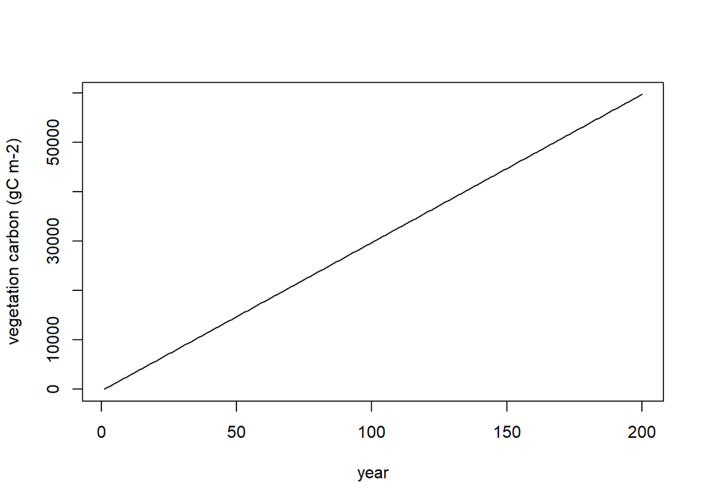

```r
#Create a vector of simulation years to use as the x-axis where the `by` argument is 1 because we want a value for each year.
years <- seq(from = 1, to = simulation_years, by = 1)
plot(x = years, y = veg, type = "l", xlab = "year", ylab = "vegetation carbon (gC m-2)")
```

**Question 10:**

What do you see in your plot?

**Answer 10:** the growth rate is linear, as expected based on the input.

## Step 8: Explore the concept of an ‘if-else statement’

Variables can be numbers, letters, or logical statements. A logical statement is either `TRUE` or `FALSE`. An ‘if-else statement’ allows for a set of calculations to occur only when a variable is `TRUE`. The following is an example

```r
print_text <- TRUE

if(print_text){
    print("Ecosystem Dynamics is the best ever!")
}
```

```
## [1] "Ecosystem Dynamics is the best ever!"
```

Did the text print below the chunk? Now run the following

```r
print_text = FALSE

if(print_text){
  print("Ecosystem Dynamics is the best ever!")
}
```

You will notice that the second one did not print text because `print_name` was `FALSE` so the calculation (e.g., print) did not occur (the area between `{ }`). More commonly ‘if-else statements’ are used to compare two numbers.

```r
a <- 1
b <- 2
if(a < b){
  print("a is less than b")
}
```

```
## [1] "a is less than b"
```

```r
if(a < 10){
  print("a is less than 10")
}
```

```
## [1] "a is less than 10"
```

An ‘if-else statement’ can also provide an alternative calculation when the value in the if statement is FALSE

```r
if(a < b){
  print("a is less than b")
}else{
  print("b is less than a")
}
```

```
## [1] "a is less than b"
```

## Step 9: Uniform random variables

Now that you can simulate the growth of an individual tree, you will work towards being able to simulate the death of an individual tree. First, you will need to explore the concept of a uniform random variable. A random variable is a value that is drawn from a probability distribution. The normal probability distribution is one that you have likely learned about in a previous course. In the case of the normal probability distribution, a value drawn from the distribution is most likely to be near the mean. Extreme values beyond two deviations are much less likely. A uniform random variable has a maximum and minimum value and all values between the maximum and minimum are equally likely. Any value outside the maximum and minimum have a 0% chance of occurring. Use the following use to explore the use of the uniform random variable.

First, here is the help page on the function we will use to randomly pick a number from the uniform distribution

```r
?runif
```

To simulate a uniform random variable use the following code

```r
lower <- 0
upper <- 1

rvar <- runif(n = 1, min = lower, max = upper)
rvar
```

```
## [1] 0.5351504
```

**Question 11:**

What value did you get for `rvar`. What value did you expect? Run the runif function again. Did you get a different answer? Why?

**Answer 11:**

## Step 10: Add mortality to tree simulation

You are going to build on your growth calculations using the ‘for-loop’ and the uniform random variable to simulate the growth and death of an individual tree. First, define the growth and define the mortality rates

```r
npp <- 300
mortality <- 0.02
```

The mortality variable is the proportion of trees that die in a year or the probability that a single tree dies in a given year. The value of 0.02 reflects a 2% chance of dying each year.

To simulate our tree, define, as you did above, the array describing the biomass of the tree in each year

```r
simulation_years <- 200
veg <- array(NA, dim = c(simulation_years))
veg[1] <- 0
```

Before proceeding, it is important to think of the tree as a space of ground where a tree grows rather than a single individual tree. Therefore, when a tree dies, a new tree replaces it. To simulate a tree dying, choose a uniform random number between 0 and 1 and ask whether the number is less than the mortality rate.

**Question 12:**

What proportion of years will the random number be less than the mortality rate?

**Answer 12:**

1/50 or (.02)

If the random number is less than the mortality rate, kill the tree by setting the biomass equal to 0 g C m-2. Use the following ‘for loop’ to simulate the space of ground that can be occupied by a single tree

```r
for(i in 2:simulation_years){
  veg[i] <- veg[i - 1] + npp
  rvar <- runif(n = 1, min = 0, max = 1)
  if(rvar < mortality){
    veg[i] <-  0
  }
}
```

**Question 13.**

Plot the tree biomass over time using the plotting commands described above.

**Answer 13:**

[figure not shown]

```r
#Insert code for the answer to question 13 here
years <- seq(1:simulation_years)
plot(x = years, y = veg, type = "l", xlab = "tree biomass", ylab = "years")
```

**Question 14:**

Describe what you see in your plot and how it relates to your code and an actual tree

**Answer 14:** The plot reflects how random the cumulative growth and the mortality of an individual tree can be. Though the parameters have not changed, it will be different each time and is stochastic.

**Question 15:**

What ecological processes are represented by the variable NPP?

**Answer 15:** net primary production- the net growth of the tree (carbon fixation). Particularly the rate at which it acquires biomass.

**Question 16:**

What ecological processes are represented by the variable mortality?

**Answer 16:** The mortality rate. The proportion of trees that will die each year, or the probability that a tree will die in a single year.

**Question 17:**

How would you find realistic values for NPP and mortality? Setting the value for these parameters in the model is called parameterizing your model.

**Answer 17:** Literature, collected data, or previous models.